# Data Wizards (Group 4) Project 1 R Notebook

Di Chen

Mai Castellano

Tyler Kussee

Spencer Hutchison

# Introduction

The American Community Survey is an ongoing survey that provides vital information on a yearly basis about our nation and it’s people. The information from the survey generates data that helps inform how trillions of dollars in federal funds are distributed.

With the data from the American Community Survey, the Data Wizards have come up with the following 3 questions they would like to answer:

- Does higher education mean higher income accounting for sex and age?
- Can we predict household income based on education, occupation, and race/ethnicity?
- Is there a relationship between race/ethnicity and home ownership?

In particular, we’ll be focusing on the first question to get started.

## Obtain the Data

In the case of the ACS dataset, we’ll pull it via an API. We’ve already declared our key earlier, so now we just need to pull our dataset with the variables and filtering we’d like. In this case we’ll want to pull our Age (AGEP), Education Level (SCHL), sex (SEX), and Total Person’s Income (PINCP) while filtering to the year 2022 and the State of OR.

## Scrub the data

Since we’ve already pulled the data, now we need to just clean up the data first. Let’s begin by assigning the column names more descriptive names:

| PersonNumber | WGTP | PWGTP | Age |
| --- | --- | --- | --- |
| 1 | 0 | 13 | 20 |
| 1 | 0 | 24 | 89 |
| 1 | 0 | 2 | 19 |
| 1 | 0 | 10 | 21 |
| 1 | 0 | 10 | 19 |
| 1 | 0 | 22 | 18 |

We can remove the the ST, Serial Number, and housing weight columns for now, since we don’t really need that information. I’ll keep PersonNumber in for now, but we can remove it if not needed.

| PersonNumber | Age | Income | EducationLevel | Sex |
| --- | --- | --- | --- | --- |
| 1 | 20 | 50000 | 16 | 1 |
| 1 | 89 | 9900 | 16 | 2 |
| 1 | 19 | 7400 | 14 | 1 |
| 1 | 21 | 17000 | 18 | 1 |
| 1 | 19 | 0 | 18 | 1 |
| 1 | 18 | 17800 | 19 | 2 |

Now we’ll clean up some of this data. in this case we’ll convert “bb” in our Education level to a 0, and then convert our Educational level to numeric values.

Now we want to create groupings of our data. In this case, we’ll be grouping education levels based on if they’ve had “No Education”, “Lower Than High School”, “High School”, “HS Diploma or GED”, “Associates Degree”, “Bachelors Degree”, “Masters Degree”, or a “Doctoral Degree”.

| PersonNumber | Age | Income | EducationLevel | Sex | EducationGroup |
| --- | --- | --- | --- | --- | --- |
| 1 | 20 | 50000 | 16 | 1 | high school diploma or GED |
| 1 | 89 | 9900 | 16 | 2 | high school diploma or GED |
| 1 | 19 | 7400 | 14 | 1 | High School |
| 1 | 21 | 17000 | 18 | 1 | high school diploma or GED |
| 1 | 19 | 0 | 18 | 1 | high school diploma or GED |
| 1 | 18 | 17800 | 19 | 2 | high school diploma or GED |
| 1 | 42 | 1600 | 17 | 1 | high school diploma or GED |
| 1 | 19 | 2000 | 19 | 2 | high school diploma or GED |
| 1 | 36 | 0 | 21 | 1 | Bachelors Degree |
| 1 | 67 | 9000 | 18 | 1 | high school diploma or GED |

[output cut: 40 more lines]

Next I’ll rearrange the columns:

| EducationGroup | EducationLevel | Income | Age | Sex | PersonNumber |
| --- | --- | --- | --- | --- | --- |
| high school diploma or GED | 16 | 50000 | 20 | 1 | 1 |
| high school diploma or GED | 16 | 9900 | 89 | 2 | 1 |
| High School | 14 | 7400 | 19 | 1 | 1 |
| high school diploma or GED | 18 | 17000 | 21 | 1 | 1 |
| high school diploma or GED | 18 | 0 | 19 | 1 | 1 |
| high school diploma or GED | 19 | 17800 | 18 | 2 | 1 |

Since we’re interested in the income of individuals, let’s remove all ages younger than 14. The legal working age of Oregon is 14 onwards.

| EducationGroup | EducationLevel | Income | Age | Sex | PersonNumber |
| --- | --- | --- | --- | --- | --- |

Now we should work on the variable codes to convert them to their actual descriptions to make the content easier to peruse. We’ll start with Education Level and convert it from it’s characters to the actual descriptions.

| EducationGroup | EducationLevel | Income | Age | Sex | PersonNumber |
| --- | --- | --- | --- | --- | --- |
| high school diploma or GED | Regular high school diploma | 50000 | 20 | 1 | 1 |
| high school diploma or GED | Regular high school diploma | 9900 | 89 | 2 | 1 |
| High School | Grade 11 | 7400 | 19 | 1 | 1 |
| high school diploma or GED | Some college, but less than 1 year | 17000 | 21 | 1 | 1 |
| high school diploma or GED | Some college, but less than 1 year | 0 | 19 | 1 | 1 |
| high school diploma or GED | 1 or more years of college credit, no degree | 17800 | 18 | 2 | 1 |
| high school diploma or GED | GED or alternative credential | 1600 | 42 | 1 | 1 |
| high school diploma or GED | 1 or more years of college credit, no degree | 2000 | 19 | 2 | 1 |
| Bachelors Degree | Bachelors Degree | 0 | 36 | 1 | 1 |
| high school diploma or GED | Some college, but less than 1 year | 9000 | 67 | 1 | 1 |

[output cut: 90 more lines]

Now lets identify the genders in the dataset:

| EducationGroup | EducationLevel | Income | Age | Sex | PersonNumber |
| --- | --- | --- | --- | --- | --- |
| high school diploma or GED | Regular high school diploma | 50000 | 20 | Male | 1 |
| high school diploma or GED | Regular high school diploma | 9900 | 89 | Female | 1 |
| High School | Grade 11 | 7400 | 19 | Male | 1 |
| high school diploma or GED | Some college, but less than 1 year | 17000 | 21 | Male | 1 |
| high school diploma or GED | Some college, but less than 1 year | 0 | 19 | Male | 1 |
| high school diploma or GED | 1 or more years of college credit, no degree | 17800 | 18 | Female | 1 |

With the data mostly cleaned up, we can now explore the data.

## Explore the data

```r
#Summarizing the ranges of numerical
summary(puma_data$Age) #Range of Age
```

```
   Min. 1st Qu.  Median    Mean 3rd Qu.    Max.
  14.00   32.00   49.00   48.95   65.00   95.00
```

```r
summary(puma_data$Income) #Range of Age
```

```
   Min. 1st Qu.  Median    Mean 3rd Qu.    Max.
 -19999    9500   28000   44307   58300 1072700
```

```r
summary(puma_data$EducationNumber) #Range of Education
```

```
Length  Class   Mode
     0   NULL   NULL
```

```r
table(puma_data$EducationLevel) #Count of each level of education
```

```
 1 or more years of college credit, no degree                             Associates Degree
                                        28173                                         14518
                             Bachelors Degree                              Doctorate Degree
                                        35076                                          2956
                GED or alternative credential                                       Grade 1
                                         7359                                            34
                                     Grade 10                                      Grade 11
                                         3998                                          4662
                        Grade 12 - no diploma                                       Grade 2
                                         3265                                            74
                                      Grade 3                                       Grade 4
                                          151                                           113
                                      Grade 5                                       Grade 6
                                          205                                           733
                                      Grade 7                                       Grade 8
                                          821                                          2886
                                      Grade 9                                  Kindergarten
                                         3408                                            40
                               Masters Degree                        No schooling completed
                                        15237                                          1844
                   Nursery School / Preschool Professional Degree beyond a Bachelors Degree
                                           37                                          3897
                  Regular high school diploma            Some college, but less than 1 year
                                        32056                                         15008
```

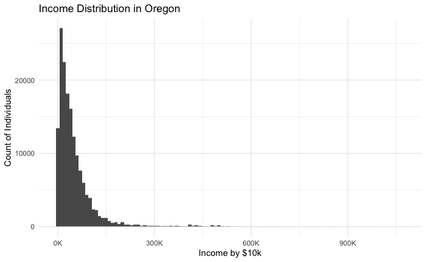

```r
ggplot(puma_data %>% filter(Income > 0), aes(Income)) +
  geom_histogram(binwidth = 10000) +
  scale_x_continuous(labels = function(x) paste0(x / 1000, "K")) +
  labs(title = "Income Distribution in Oregon"
       , x = "Income by $10k"
       , y = "Count of Individuals") +
  theme_minimal()
```

[Reference on Variables for now](https://usa.ipums.org/usa/resources/codebooks/DataDict1822.pdf)

## Model the data

| EducationGroup | EducationLevel | Income | Age | Sex | PersonNumber |
| --- | --- | --- | --- | --- | --- |
| high school diploma or GED | Regular high school diploma | 50000 | 20 | Male | 1 |
| high school diploma or GED | Regular high school diploma | 9900 | 89 | Female | 1 |
| High School | Grade 11 | 7400 | 19 | Male | 1 |
| high school diploma or GED | Some college, but less than 1 year | 17000 | 21 | Male | 1 |
| high school diploma or GED | 1 or more years of college credit, no degree | 17800 | 18 | Female | 1 |
| high school diploma or GED | GED or alternative credential | 1600 | 42 | Male | 1 |
| high school diploma or GED | 1 or more years of college credit, no degree | 2000 | 19 | Female | 1 |
| high school diploma or GED | Some college, but less than 1 year | 9000 | 67 | Male | 1 |
| high school diploma or GED | GED or alternative credential | 8800 | 52 | Male | 1 |
| No schooling completed | No schooling completed | 11100 | 51 | Female | 1 |

[output cut: 990 more lines]

| EducationGroup | EducationLevel | Income | Age | Sex | PersonNumber |
| --- | --- | --- | --- | --- | --- |
| high school diploma or GED | Regular high school diploma | 50000 | 20 | Male | 1 |
| high school diploma or GED | Regular high school diploma | 9900 | 89 | Female | 1 |
| High School | Grade 11 | 7400 | 19 | Male | 1 |
| high school diploma or GED | Some college, but less than 1 year | 17000 | 21 | Male | 1 |
| high school diploma or GED | 1 or more years of college credit, no degree | 17800 | 18 | Female | 1 |
| high school diploma or GED | GED or alternative credential | 1600 | 42 | Male | 1 |

##Check the assumption

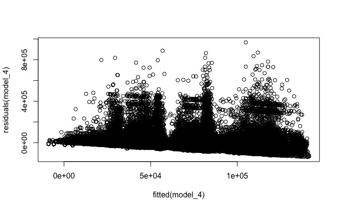

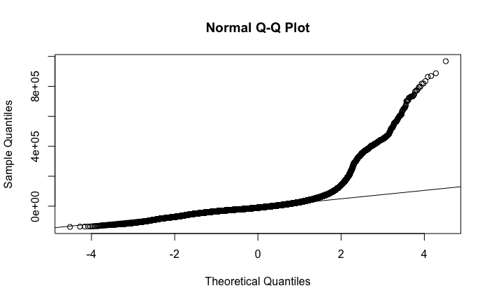

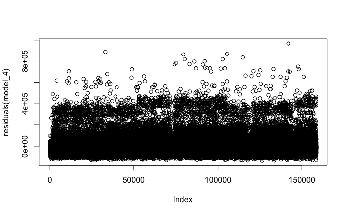

Consider log transformation of the response variable:

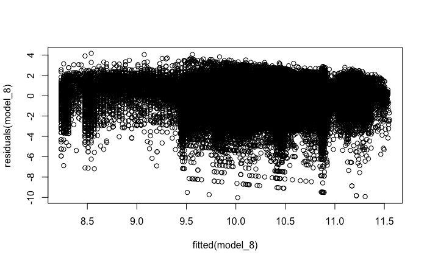

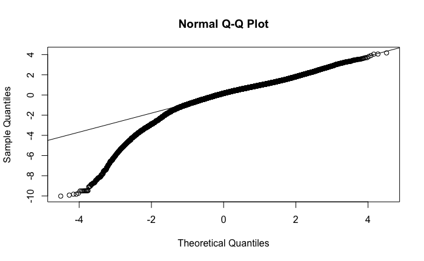

## Interpret the data

To answer our question, does higher education mean higher income accounting for sex and age? Use the fitted model to compare the income across all 8 levels of education for a 50 years old males and females in Oregon.

It appears that the average income for a 50-year-old male in Oregon varies significantly across different educational categories. Starting with individuals who have no schooling completed, their average income is $19,927.16, slightly lower than the average income for those with less than a high school education, which stands at $21,855.60. Surprisingly, individuals with only a high school education (without a diploma) experience a decrease in average income to $14,441.65, suggesting that completing high school does not necessarily lead to improved income prospects for this demographic.

However, there is a notable increase in average income for individuals with a high school diploma or GED, reaching $26,611.61. From this point onward, it seems that higher levels of education correspond to higher average incomes for this demographic. For instance, individuals with an associate’s degree experience a substantial increase in average income to $37,603.97. Further up the educational ladder, those with a bachelor’s degree see a significant jump in average income to $53,105.31. Pursuing even higher education, individuals with a master’s degree experience a further increase in average income to $74,404.36, while those with a doctorate degree have the highest average income of $87,990.00.

The average income for 50-year-old females in Oregon also exhibits variations across different educational categories. Starting with individuals who have no schooling completed, their average income is $13,670.589. This increases slightly for those with less than a high school education, reaching $14,888.971. Surprisingly, individuals with only a high school education (without a diploma) experience a decrease in average income to $9,206.923, similar to the trend observed among males.

However, there is a significant increase in average income for females with a high school diploma or GED, rising to $17,306.203. This trend continues as educational attainment increases. For instance, individuals with an associate’s degree experience a substantial increase in average income to $24,280.252. Further up the educational ladder, those with a bachelor’s degree see a significant jump in average income to $33,974.807.

Despite these initial similarities, males tend to experience higher average incomes compared to females in the higher educational categories. For example, males with a bachelor’s, master’s, or doctorate degree generally have higher average incomes than their female counterparts with the same level of education.